# Tutorial 7 Network models II

1. The Watts-Strogatz model
2. The Newman-Watts model
3. Small-world routing

```python
import networkx as nx
import numpy as np
import matplotlib as mpl
import matplotlib.pyplot as plt
%matplotlib inline

nx.__version__, mpl.__version__
```

```
('3.1', '3.5.2')
```

A real network has

1. a scale-free degree distribution $P_k$,
2. a high average clustering coefficient $C$, and
3. a short average shortest path length $L$.

In terms of social networks, the three features mean that

1. most people are anonymous, whereas a few are very famous;
2. my friends' friends are usually my friends; and
3. we are connected via a strikingly small number of interpersonal relationships.

A small-world network is a network that possesses a high $C$ and a short $L$ but lacks a scale-free $P_k$. In fact, "small-world network" is kind of a misnomer because random networks also possess the **small-world property** $L\sim\ln{N}$. What truly distinguishes small-world networks from random ones is their exceptionally high $C$.

# 1. The Watts-Strogatz model

Although social scientists have long noticed that our worlds are small (Milgram, 1967), no one could systematically explain its origin until [Watts and Strogatz (1998)](https://www.nature.com/articles/30918) proposed their pioneering network model.

## 1.1 Algorithm

The Watts-Strogatz (WS) model defines a network with its size $N$, average degree $K$ (which is an even number), and **rewiring probability** $p$. It starts from a $K$-regular ring, i.e. a ring that additionally connects every node to its nearest $K-2$ neighbors. Then for each node $i$, the model **rewires** its $\frac{1}{2}K$ anticlockwise edges with probability $p$, meaning that every edge $\left(i,j\right)$ is replaced with $\left(i,h\right)$ for some node $h$. To avoid self-loops or multi-edges, $h$ must not be $i$ or $i$'s neighbours, but $h$ may be chosen to be $j$.

You can construct a WS network with `watts_strogatz_graph`. We often require $N\gg K\gg\ln{N}\gg1$ so that the resultant WS network behaves desirably: while being connected, it will not be as dense as a complete network.

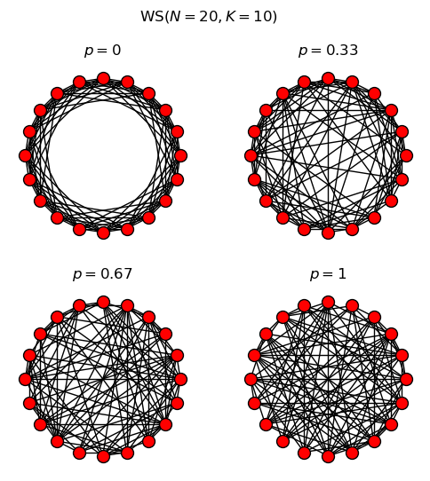

```python
ws = nx.watts_strogatz_graph
N, K = 20, 10
fig, ax = plt.subplots(2, 2, figsize=(6, 6))
fig.suptitle(r'$\mathrm{WS}{\left(N=%d, K=%d\right)}$' % (N, K))
for i, a in enumerate(ax.flat):
    nx.draw_circular(ws(N, K, p=i/3, seed=5056), ax=a,
                     node_size=100, node_color='r', edgecolors='k')
    a.set_title('$p=%.2g$' % (i/3))
```

At $p=0$, a WS network is simply a regular ring. It becomes more and more disordered as $p$ grows. At $p=1$, all edges are rewired, so it is a random network.

We know that a regular ring has a high $C$ and a long $L$, whereas a random network has a low $C$ and a short $L$. Here comes an interesting question: how does a WS network's $C$ and $L$ change as a function of $p$?

## 1.2 Properties

### Degree distribution.

A WS network shows a bell-shaped $P_k$. At $p=0$, $P_k$ is just a Dirac delta $\delta{\left(k-K\right)}$. As $p$ grows, $P_k$ gradually gets wider, and it becomes the widest at $p=1$. Letting $H=\frac{1}{2}K$, the degree distribution reads ([Barrat and Weigt, 2000](https://link.springer.com/article/10.1007/s100510050067))

\begin{align} P_k = \sum_{n=0}^{\min{\left(k-H,H\right)}} { \left(\matrix{H\\n}\right)(1-p)^n p^{H-n} \dfrac{\left(pH\right)^{k-H-n}} {\left(k-H-n\right)!} e^{-pH} }\,. \end{align}

Although a WS network is completely random at $p=1$, notice that $P_k{\left(p=1\right)}$ is not identical to that of an ER network with $\langle{k}\rangle=K$ because the two models have different algorithms for graph construction. Their biggest difference lies upon the the fact that all nodes in a WS network are guaranteed to have at least $\frac{1}{2}K$ edges even after the network is completely rewired.

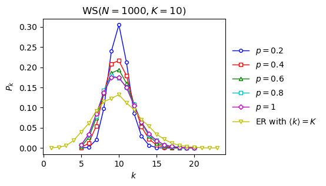

```python
def add_unequally_long_lists(list1, list2):
    if len(list1) < len(list2): short, long = list1, np.array(list2)
    else: short, long = list2, np.array(list1)
    long[:len(short)] += short
    return long
def add_list_of_lists(list_of_lists):
    sum_ = list_of_lists[0]
    for list_ in list_of_lists[1:]:
        sum_ = add_unequally_long_lists(sum_, list_)
    return sum_

N, K = 1000, 10
ps = [.2, .4, .6, .8, 1, 'ER']
trials = 10
er = nx.fast_gnp_random_graph
degHist = nx.degree_histogram

plt.figure(figsize=(4, 3))
for p, cs in zip(ps, ['bo', 'rs', 'g^', 'cs', 'mD', 'yv']):
    if p != 'ER': hists = [degHist(ws(N, K, p, 5056+t)) for t in range(trials)]
    else: hists = [degHist(er(N, K/(N-1), 5056+t)) for t in range(trials)]
    hist = add_list_of_lists(hists)
    kMin = np.argmax(np.array(hist)>0)
    plt.plot(range(kMin, len(hist)), [h/N/trials for h in hist[kMin:]],
             cs+'-', lw=1, ms=4, mfc='w', label=(
                 '$p=%g$'%p if p != 'ER' else r'ER with $\langle{k}\rangle=K$'))
plt.legend(loc='center left', bbox_to_anchor=(1, .5), frameon=False)

plt.title(r'$\mathrm{WS}{\left(N=%d, K=%d\right)}$' % (N,K))
plt.xlabel('$k$')
plt.ylabel('$P_k$')
plt.show()
```

### Clustering coefficient.

A $K$-regular ring has $C{\left(0\right)}=\dfrac{3}{4}\dfrac{K-2}{K-1}$. Because every edge is rewired with probability $p$, triangles in the ring remain intact with probability $\left(1-p\right)^3$. This implies a rough estimate of $C{\left(p\right)}$.

\begin{align} C{\left(p\right)} \approx \dfrac{3}{4} \dfrac{K-2}{K-1} \left(1-p\right)^3 \end{align}

This estimation is particularly inaccurate when $p$ is large because it ignores the new triangles formed after rewiring. However, the probability of the new triangles vanishes when $N\gg K$.

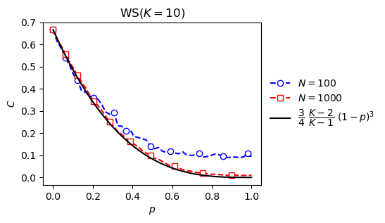

```python
N1, N2, K = 100, 1000, 10
C = nx.average_clustering
ps = np.linspace(0, 1)

plt.figure(figsize=(4, 3))
plt.plot(ps, [C(ws(N1, K, p, 5056)) for p in ps],
         'bo--', mfc='w', markevery=.1, label='$N=%d$' % N1)
plt.plot(ps, [C(ws(N2, K, p, 5056)) for p in ps],
         'rs--', mfc='w', markevery=.1, label='$N=%d$' % N2)
plt.plot(ps, .75*(K-2)/(K-1)*(1-ps)**3, 'k',
         label=r'$\dfrac{3}{4}\ \dfrac{K-2}{K-1}\ \left(1-p\right)^3$')
plt.legend(loc='center left', bbox_to_anchor=(1, .5), frameon=False)

plt.title(r'$\mathrm{WS}{\left(K=%d\right)}$' % K)
plt.xlabel('$p$')
plt.ylabel('$C$')
plt.show()
```

### Shortest path length.

When $p$ is close to $0$, a WS network gives $L{\left(0^+\right)}\approx\dfrac{N}{2K}\sim N$. On the other hand, when $p$ approaches $1$, the small-world property emerges, so $L{\left(1^-\right)}\approx\dfrac{\ln{N}}{\ln{K}}\sim\ln{N}$. However, no one can analyze the drop in $L{\left(p\right)}$ so far, whereas [Barthélémy and Amaral (1999)](https://journals.aps.org/prl/abstract/10.1103/PhysRevLett.82.3180) offered a very primitive framework for the analysis.

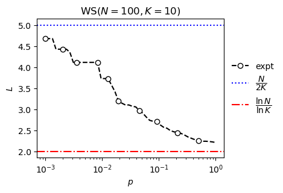

```python
N, K = 100, 10
L = lambda G: nx.floyd_warshall_numpy(G).sum()/(N*(N-1))
ps = np.logspace(-3, 0)

plt.figure(figsize=(4, 3))
plt.plot(ps, [L(ws(N, K, p, 5056)) for p in ps],
         'ko--', mfc='w', markevery=.1, label='expt')
plt.axhline(N/(2*K), c='b', ls=':',
            label=r'$\dfrac{N}{2K}$')
plt.axhline(np.log(N)/np.log(K), c='r', ls='-.',
            label=r'$\dfrac{\ln{N}}{\ln{K}}$')
plt.legend(loc='center left', bbox_to_anchor=(1, .5), frameon=False)

plt.title(r'$\mathrm{WS}{\left(N=%d, K=%d\right)}$' % (N, K))
plt.xlabel('$p$')
plt.ylabel('$L$')
plt.xscale('log')
plt.show()
```

## 1.3 Physics of the clustered small world

You will see that for some $p$, the resultant WS network strikingly possesses both a high $C$ and a short $L$. The WS model thus marks a milestone of network science: scientists can finally reason the coexistence of clustering and small-world effect on real networks.

While short-range friendships keeps our world highly clustered,

long-range friendships act as shortcuts to pull us much closer to each other.

Still, the WS model is not perfect because it fails to yield a scale-free degree distribution and thus fails to describe celebrities' existence. Anyhow, Watts and Strogatz's inspiring results sparked a wave of researches about small-world phonemona. Their model (along with Barabási and Albert's one, which you will learn in Lecture 8) have brought network science to a new era.

```python
# try to locate the regime where
# a WS network has a high C and a short L

# this is your second lab!
```

## 2. The Newman-Watts model

Although the Watts-Strogatz model is insightful, it is too tough to analyse this pioneering model's properties. Therefore, [Newman and Watts](https://www.sciencedirect.com/science/article/abs/pii/S0375960199007574?via%3Dihub) amended it slightly to get a mathematically simpler model (1999a), namely the Newman-Watts (NW) model.

## 2.1 Algorithm

The NW model specifies three parameters for a network, including its size $N$, initial average degree $K$, and **shortcut probability** $p$. It also starts from a $K$-regular ring. Then, for every edge in the ring, the model adds a random edge with a probability $p$, so it adds around $\frac{1}{2}NKp$ random edges to the ring. When they choose the new edge, Newman and Watts does not prohibit the possibility of self-loops and multi-edges for statistical simplicity. After adding the edges, the NW network has an average degree $\langle{k}\rangle=K\left(1+p\right)$.

You can construct an "NW network" with `newman_watts_strogatz_graph`. The returned network is, however, statistically a bit different from Newman and Watts's prescription because the function explicitly bans self-loops and multi-edges. Still, the deviance is expected to diminish as $N\gg K$.

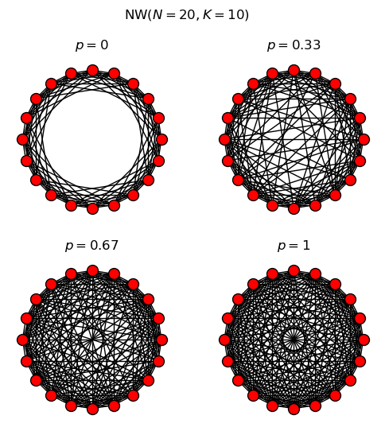

```python
nw = nx.newman_watts_strogatz_graph # statistically inaccurate

N, K = 20, 10
fig, ax = plt.subplots(2, 2, figsize=(6, 6))
fig.suptitle(r'$\mathrm{NW}{\left(N=%d, K=%d\right)}$' % (N, K))
for i, a in enumerate(ax.flat):
    nx.draw_circular(nw(N, K, p=i/3, seed=5056), ax=a,
                     node_size=100, node_color='r', edgecolors='k')
    a.set_title('$p=%.2g$' % (i/3))
```

## 2.2 Properties

When $p$ is small, the NW model behaves similarly to the WS model. On the other hand, the NW model behaves nicer than the WS model at a large $p$, and its nice behaviours help us derive its characteristic properties.

### Degree distribution.

Since $\frac{1}{2}NKp$ edges brings $NKp$ ends of edges, every node receives around $pK$ ends of edges. The probability that a node receives exactly $x$ ends follows a Poisson distribution

\begin{align} P_x = \dfrac{\left(pK\right)^x}{x!} e^{-pK}\,. \end{align}

As $k=K+x$, the NW model's degree distribution reads

\begin{align} P_k = \dfrac{\left(pK\right)^{\left(k-K\right)}}{\left(k-K\right)!} e^{-pK}\,. \end{align}

Due to its algorithm, $k$ is always at least $K$. (A WS network similarly always gives $k\geq\frac{1}{2}K$.)

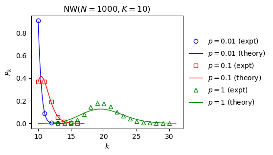

```python
from scipy.special import factorial
N, K = 1000, 10
ps = [.01, .1, 1]
trials = 10

plt.figure(figsize=(4, 3))
for p, fmt in zip(ps, ['bo', 'rs', 'g^']):
    hist = add_list_of_lists([
        degHist(nw(N,K,p,5056+t))for t in range(trials)])
    kMin = np.argmax(np.array(hist)>0)
    plt.plot(range(kMin, len(hist)), [h/N/trials for h in hist[kMin:]],
             fmt, ms=6, mfc='none', label= r'$p=%g$ (expt)'%p)
    ks = np.linspace(K, len(hist))
    plt.plot(ks, (p*K)**(ks-K)/factorial(ks-K)*np.exp(-p*K),
             fmt[0]+'-', lw=1, label=r'$p=%g$ (theory)'%p)
plt.legend(loc='center left', bbox_to_anchor=(1, .5), frameon=False)

plt.title(r'$\mathrm{NW}{\left(N=%d, K=%d\right)}$'%(N,K))
plt.xlabel('$k$')
plt.ylabel('$P_k$')
plt.show()
```

### Transitivity.

Recall the definition of a network's transitivity $T$ (aka global clustering coefficient $C_\Delta$).

\begin{align} T = 3\times\dfrac{\text{# triangles}}{\text{# triads}} \end{align}

It is similar but not identical to the average clustering cofficient $C$. It turns out that instead of $C$, we can analyze an NW network's transitivity [Newman's Chapter 15 (2010)].

\begin{align} T{\left(p\right)} = \dfrac{3\left(K-2\right)}{4\left(K-1\right)+4Kp\left(p+2\right)} \end{align}

In particular, the formula gives $T{\left(0\right)}=\dfrac{3}{4}\dfrac{K-2}{K-1}$ and $T{\left(1\right)}=\dfrac{3}{4}\left(\dfrac{K-2}{4K-1}\right)$.

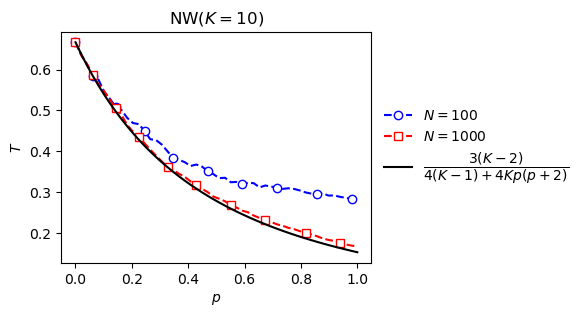

```python
N1, N2, K = 100, 1000, 10
T = nx.transitivity
ps = np.linspace(0, 1)

plt.figure(figsize=(4, 3))
plt.plot(ps, [T(nw(N1, K, p, 5056)) for p in ps],
         'bo--', mfc='w', markevery=.1, label='$N=%d$' % N1)
plt.plot(ps, [T(nw(N2, K, p, 5056)) for p in ps],
         'rs--', mfc='w', markevery=.1, label='$N=%d$' % N2)
plt.plot(ps, 3*(K-2)/(4*(K-1)+4*K*ps*(ps+2)), 'k',
         label=r'$\dfrac{3\left(K-2\right)}{4\left(K-1\right)+4Kp\left(p+2\right)}$')
plt.legend(loc='center left', bbox_to_anchor=(1, .5), frameon=False)

plt.title(r'$\mathrm{NW}{\left(K=%d\right)}$' % K)
plt.xlabel('$p$')
plt.ylabel('$T$')
plt.show()
```

### Shortest Path Length.

Through a dimensional analysis, [Newman and Watts (1999b)](https://journals.aps.org/pre/abstract/10.1103/PhysRevE.60.7332) argued that an NW network's $L$ must universally obey

\begin{align} \dfrac{K}{N} L = f{\left({NKp}\right)} \end{align}

for some function $f$. Experimentally we observe that $L\sim\ln{N}$ when $N\gg K$ and $p\rightarrow1$, so $f{\left(x\right)}$ has to be asymptotic to $\dfrac{\ln{x}}{x}$ as $x\rightarrow\infty$. Later, [Newman, Moore, and Watts (2002)](https://journals.aps.org/prl/abstract/10.1103/PhysRevLett.84.3201) estimated $f{\left(x\right)}$ with **mean-field theory**, which originates from statistical physics.

\begin{align} f{\left(x\right)} &\approx \dfrac{2}{\sqrt{x^2+4x}}\,\tanh^{-1}{\sqrt{\dfrac{x}{x+4}}} \\ &= \dfrac{1}{\sqrt{x^2+4x}}\,\ln {\dfrac{\sqrt{1+4/x}+1}{\sqrt{1+4/x}-1}} \end{align}

It indeed approaches $\dfrac{\ln{x}}{x}$ at a large $x$. The approximation is accurate when $x=NKp$ is very large or very small.

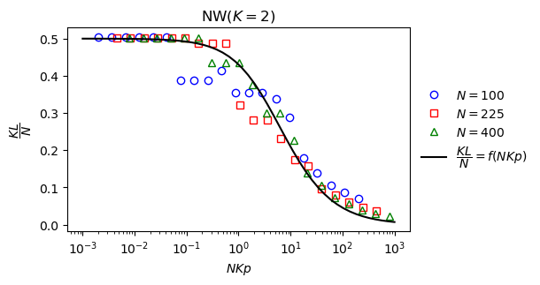

```python
def f(x):
    y = (1+4/x)**.5
    return (x**2+4*x)**-.5 * np.log((y+1)/(y-1))
f = np.frompyfunc(f, 1, 1)

def breadth_first_search(G):
    dists = np.full((len(G), len(G)), -1, int)
    np.fill_diagonal(dists,0)
    for i in G:
        read, visited = 0, [i]
        while read < len(visited):
            u, read = visited[read], read+1
            d = dists[i, u]
            for v in G[u]:
                if dists[i, v] < 0:
                    dists[i, v] = d+1
                    visited += [v]
    return dists
# breadth-first search (BFS): O(N*(N+E))
# Floyd-Warshall (FW):        O(N^3)

Ns, K = [100, 225, 400], 2
ps = np.logspace(-5, 0, 20)
xs = np.logspace(-3, 3)

plt.figure(figsize=(5, 3))
for N, cs in zip(Ns, ['bo','rs','g^']):
    plt.plot(ps*N*K, [K/N*breadth_first_search(nw(N,K,p,5056)).sum()/(N*(N-1))
                      for p in ps], cs, mfc='none', label='$N=%d$' % N)
plt.plot(xs, f(xs), 'k', label=r'$\dfrac{KL}{N}=f\left(NKp\right)$')
plt.legend(loc='center left', bbox_to_anchor=(1, .5), frameon=False)

plt.title(r'$\mathrm{NW}\left(K=2\right)$')
plt.xlabel('$NKp$')
plt.ylabel('$\dfrac{KL}{N}$')
plt.xscale('log')
plt.show()
```

## 2.3 Mathematics of the clustered small world

According to the anlaysis, the small-world effect $L\sim\ln{N}$ emerges when $NKp\gg1$. Since $NKp$ is twice the number of shortcuts, the condition $NKp\gg1$ means that an NW network becomes a small world once we add sufficient shortcuts. If $N\rightarrow\infty$, even a tiny $p\rightarrow0^+$ can result in $NKp\gg1$, so an enormous NW network just needs a low density of shortcuts. At the same time, the netowork is highly clustered as its transitivity $T{\left(p\rightarrow0^+\right)}$ is high.

After all, the NW model helps us understand a clustered smalled world mathematically better.

# 3. Small-world routing

Although they physically and mathematically explain our clustered small world, the WS model and the NW model do not truly explain the impressive results of **Milgram's small-world experiment**. The participants of the experiment could deliver their letters successfully not just because the world was small. Another crucial reason was that before sending ther letters, the participants could reasonably guess which of their friends were closer to their targets, and this allowed the letters to get progressively closer to their targets. Overall,

while a small world does have short distances between nodes,

not every small world favours an efficient routing of information among nodes.

Do not forget that a random network is also a small world: do you expect an efficent delivery of information on a small but **messy** world?

## 3.1 Reproducing the small-world experiment

[Kleinberg (2000)](https://www.nature.com/articles/35022643) numerically reproduced the small-world experiment on a periodic square lattice, where each node represents a participant of the experiment. But for simplicity, I will follow Newman's Chapter 19 (2010) here and replaces the square lattice with a ring.

In the experiment, a source node $s$ tries to deliver a message to a target node $t$ by passing it to a neighbour, who repeats this step after receiving the message. Every node $i$ only knows three things, i.e.

1. his own coordinate $x_i$ (which ranges from $0$ to $N-1$ on an $N$-node ring),
2. his neighbours' coordinates $\{x_j\}$, and
3. his targets's coordinate $x_t$.

When $i$ receives the message, he **greedily** passes the message to the neighbour $j$ whom **he thinks** is the closest to $t$. Since he does not know the existence of shortcuts, he simply assumes that the distance between any two nodes $u$ and $v$ is their distance $r_{uv}$ on the ring.

\begin{align} r_{uv} = \min{\left( \lvert{x_u-x_v}\rvert, \lvert{x_u-x_v+N}\rvert, \lvert{x_v-x_u+N}\rvert \right)} \end{align}\begin{align} j = \underset{h:i\text{'s neighbours}}{\mathrm{argmin}}\ r_{ht} \end{align}

Now, we would like to measure the delivery time $T$ (in number of edges) of the message. If there are no shortcuts, $T\sim N^{1/d}$ on a $d$-dimensional lattice, so $T\sim N$ on a ring.

```python
def delivery_time(G, s, t):
    if s == t: return 0
    N = len(G)
    nbrs = list(G[s])
    r = [min(abs(i-t), abs(i-t+N), abs(t-i+N)) for i in nbrs]
    return delivery_time(G, nbrs[np.argmin(r)], t)+1
```

### Failure of uniformly random shortcuts.

Kleinberg first tested whether $T$ is reduced after adding some **uniformly random** shortcuts.

- Kleinberg showed that for a square lattice, $T\sim N^{1/3}$ despite $L\sim\ln{N}$.
- If the base network is a ring instead, adding uniformly random shortcuts creates an NW network and gives $T\sim N$ despite $L\sim\ln{N}$.

The observation implies that if shortcuts in our world indeed emerged in a uniformly random way (as the WS model and the NW model suggests), Milgram's small-world experiment would have spent a much longer time, and it would have never been able to reveal how small our world is.

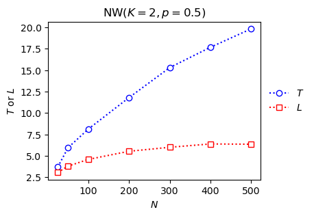

```python
Ns = [25, 50, 100, 200, 300, 400, 500]
p = .5 # an arbitrary value

Ts, Ls = [], []
for N in Ns:
    G = nw(N, 2, p, seed=5056)
    Ts += [sum(delivery_time(G, s, t) for s in range(N)
               for t in range(N) if s<t) / (N*(N-1)/2)]
    Ls += [breadth_first_search(G).sum() / (N*(N-1))]

plt.figure(figsize=(4, 3))
plt.plot(Ns, Ts, 'bo:', mfc='w', label='$T$')
plt.plot(Ns, Ls, 'rs:', mfc='w', label='$L$')
plt.legend(loc='center left', bbox_to_anchor=(1, .5), frameon=False)
plt.xlabel('$N$')
plt.ylabel('$T$ or $L$')
plt.title(r'$\mathrm{NW}{\left(K=2, p=%.3g\right)}$' % p)
plt.show()
```

## 3.2 The Kleinberg model

Kleinberg argued that real shortcuts are certianly not uniformly random but **biased** to factors like similar personality or short geographical separation, so he invented the Kleinberg model. If the distance between $u$ and $v$ is $r_{uv}$ on the base network, the Kleinberg model adds a shortcut edge $\left(u, v\right)$ with a probability proportional to $r_{uv}^{-\alpha}$. The parameter $\alpha$ is called the "**clustering exponent**".

- If $\alpha=0$, the shortcuts are uniformly random.
- If $\alpha\to\infty$, there are no shortcuts at all.

Note that Kleinberg did not thoroughly explain the details of how to generate the probabilities. The following implementation follows Newman's interpretation, so I am calling it the Kleinberg-Newman (KN) model here.

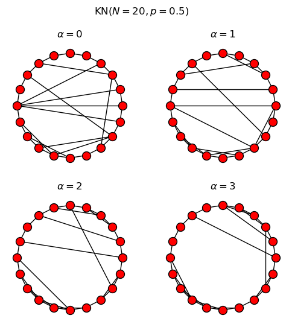

```python
def kleinberg_newman_graph(N, p, alpha, seed):
    # Kleinberg's model with Newman's interpretation
    np.random.seed(seed)
    G = nx.empty_graph(N)
    rMax = (N-N%2)//2
    for i in range(N):
        G.add_edge(i, (i+1)%N)
        if np.random.random() < p:
            r = np.arange(2, rMax+1).astype(float)
            prob = r**-alpha; prob /= np.sum(prob)
            j = (i+np.random.choice(r, p=prob))%N
            G.add_edge(i, j)
    return G
kn = kleinberg_newman_graph

N, p = 20, .5
fig, ax = plt.subplots(2, 2, figsize=(6, 6))
fig.suptitle(r'$\mathrm{KN}{\left(N=%d, p=%.3g\right)}$' % (N, p))
for i, a in enumerate(ax.flat):
    nx.draw_circular(kn(N, p, alpha=i, seed=5056), ax=a,
                     node_size=100, node_color='r', edgecolors='k')
    a.set_title(r'$\alpha=%.2g$' % i)
```

Kleinberg proved that as $N$ grows, the clustering exponent $\alpha$ crucially determines the participants' performance in the small-world experiment.

- On a square lattice,

\begin{align} T\sim N^\beta\quad\text{for}\quad \ \beta = \begin{cases} \dfrac{2-\alpha}{6} & \left(\alpha<2\right) \\ \dfrac{\alpha-2}{2\left(\alpha-1\right)} & \left(\alpha>2\right) \end{cases}\,. \end{align}

- On a ring,

\begin{align} T\sim N^\beta\quad\text{for}\quad \ \beta = \begin{cases} 1-\alpha & \left(\alpha<1\right) \\ \alpha-1 & \left(\alpha>1\right) \end{cases}\,. \end{align}

Therefore, the **critical cluster exponent** is $\alpha^*=2$ for a square lattice, whereas it is $\alpha^*=1$ for a ring. When $\alpha=\alpha^*$, the delivery time $T\sim\ln^2{N}$ drops to its minimum and becomes **logarithmic** in both cases.

It is however hard to verify this analysis numerically because it is only valid when $N$ is large, which requires an intensive simulation (at least too intensive for this tutorial). If $N$ is not large enough, the behaviour of $\beta$ deviates from the prediction. Kleinberg actually tested his theory using 1000 trials at $N=4\times10^7$, yet he could only measure $\alpha^*\approx1.8$.

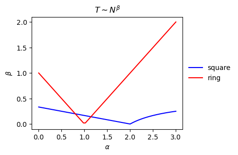

```python
alphas = np.concatenate((np.linspace(0, 2), np.linspace(2, 3)))
beta_square = np.frompyfunc(lambda a: (2-a)/6 if a<2 else .5-.5/(a-1), 1, 1)
beta_ring = lambda a: np.abs(1-a)

plt.figure(figsize=(4, 3))
plt.plot(alphas, beta_square(alphas), 'b-', label='square')
plt.plot(alphas, beta_ring(alphas), 'r-', label='ring')
plt.legend(loc='center left', bbox_to_anchor=(1, .5), frameon=False)

plt.title(r'$T\sim N^\beta$')
plt.xlabel(r'$\alpha$')
plt.ylabel(r'$\beta$')
plt.show()
```

### Critical clustering exponent.

Kleinberg showed that there is an "optimal level" of bias. If there is insufficient ($\alpha<\alpha^*$) or excessive bias ($\alpha>\alpha^*$), the small-world experiment fails. Only when the amount of bias is suitable ($\alpha=\alpha^*$), $T$ becomes a logarithmic function of $N$. Note that $T$ scales with $\ln^2{N}$ instead of $\ln{N}$ even in the optimal case. This means that the participants' greedy algorithm is not the best algorithm for delivering a message.

Here comes an intersting question: Why is $\alpha^*=2$ on a square lattice but $\alpha^*=1$ on a ring? In fact, the critical clustering exponent is the **dimension** $d$ of the base network. Kleinberg explained it in the following way: on a $d$-dimensional lattice, the source $s$ has around $N_r\sim r^d$ neighbours $r$ steps away, so around $N_r r^{-\alpha}\sim r^{d-\alpha}$ nodes becomes $s$'s neighbours via shortcuts. Now, suppose $s$ wants to send a message to the target $t$.

- If $\alpha>d$, $r^{d-\alpha}$ decreases with $r$. Long-range shortcuts are thus rare, and most of $s$'s shortcuts stay inside his vicinity. The message is then trapped near $s$ and can only reach $t$ by slowly traversing multiple short-range shortcuts.
- If $\alpha<d$, $r^{d-\alpha}$ increases with $r$, so long-range shortcuts are abundant, helping the message quickly reach the vicinity of $t$. After that, however, there are too few short-range shortcuts linking to $t$, so the message cannot exploit any shortcuts by wastes time traversing the edges on the base network to reach $t$.
- If $\alpha=d$, $r^{d-\alpha}=1$, so all nodes possess some short-range and some long-range shortcuts. Consequently, the message can always always utilize some shortcuts regardless of its distance to $t$.

After all, Kleinberg helped us interpret the impressive results of Milgran's small-world experiment better:

Our clustered small world is never arbitrarily formed but meaningfully structured.

# References

1. Barrat A. and Weigt M. (2000) *On the properties of small-world network models*, Eur. Phys. J. B. **13**, 547.
2. Barthélémy M. and Amaral L. A. N. (1999) *Small-World Networks: Evidence for a Crossover Picture* Phys. Rev. Lett. **82**, 3180.
3. Kleinberg J. (2000) *Navigation in a small world*, Nature **406**, 845.
4. Milgram S. (1967) *The Small World Problem*, Psychology Today **2**, 60.
5. Newman M. E. J. (2010) *Networks: An Introduction* (Oxford University Press, Oxford).
6. Newman M. E. J. and Watts D. J. (1999a) *Renormalization group analysis of the small-world network model*, Phys. Lett. **263**, 341, 1999.
7. Newman M. E. J. and Watts D. J. (1999b) *Scaling and percolation in the small-world network model*, Phys. Rev. E **60**, 7332.
8. Newman M. E. J., Moore C., and Watts D. J. (2002) *Mean-Field Solution of the Small-World Network Model*, Phys. Rev. Lett. **84**, 3201.
9. Watts D. J. and Strogatz S. H. (1998) *Collective dynamics of 'small-world' networks*, Nature **393**, 440.